# queues slides

## Queues

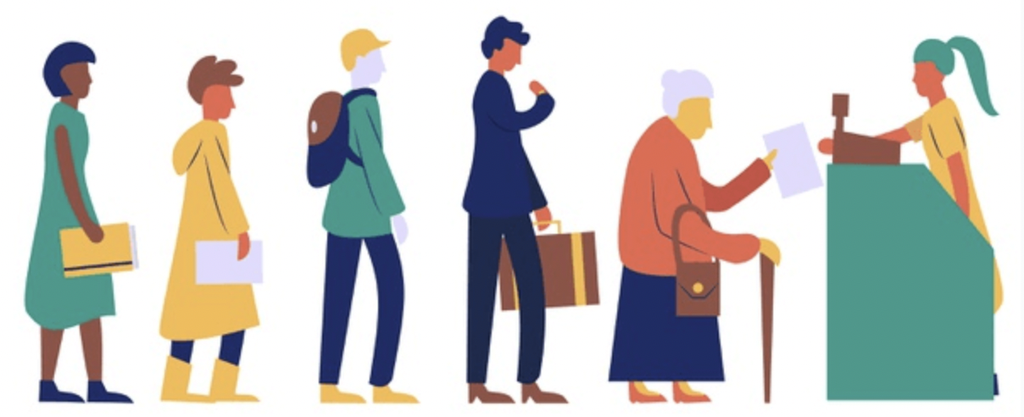

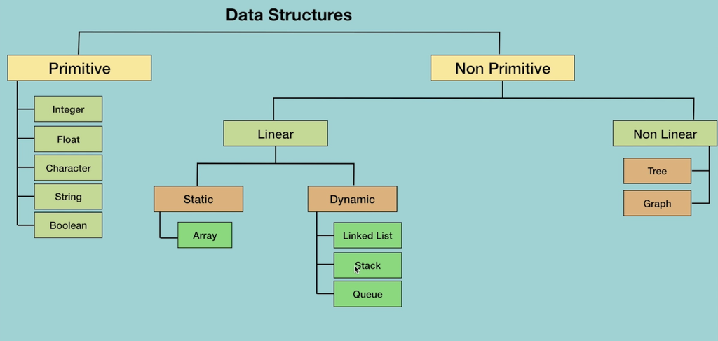

### Queues

- People waiting in line to be served
- Used to implement a first-in first-out (FIFO) type protocol

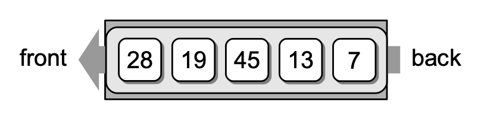

### Queue

- A queue is a linear data structure
- Access limited to a first-in first-out order.
- Adding happens at the back, and leaving happens at the front of the queue.
- An empty queue contains no items.

### Queue and operations

- $\tt Queue\;$( ): Creates a new empty queue, which is a queue containing no items.
- $\tt isEmpty\;$( ): Returns a boolean value indicating whether the queue is empty.
- $\tt length\;$( ): Returns the number of items currently in the queue.
- $\tt enqueue( item )\;$: Adds the given item to the back of the queue.
- $\tt dequeue\;$( ): Removes and returns the front item from the queue. An item cannot be dequeued from an empty queue.

```python
# Implementation of the Queue ADT using a Python list.
class Queue :
    # Creates an empty queue.
    def __init__( self ):
        self._qList = list()

    # Returns True if the queue is empty.
    def isEmpty( self ):
        return len( self ) == 0

    # Returns the number of items in the queue.
    def __len__( self ):
        return len( self._qList )

    # Adds the given item to the queue.
    def enqueue( self, item ):
        self._qList.append( item )

    # Removes and returns the first item in the queue.
    def dequeue( self ):
        assert not self.isEmpty(), "Cannot dequeue from an empty queue."
        return self._qList.pop( 0 )
```

```python
myQ = Queue()

print(myQ.isEmpty())
myQ.enqueue(28)
print(myQ.isEmpty())
myQ.enqueue(19)
myQ.enqueue(45)


print(myQ.dequeue())
print(myQ.dequeue())
print(myQ.dequeue())
print(myQ.dequeue())
```

- $\tt isEmpty(\;)$: $O(1)$
- $\tt length(\;)$: $O(1)$
- $\tt enqueue(\;)$: $O(1)$
- $\tt dequeue(\;)$: $O(n)$
- $\tt enqueue(\;)$: $O(1)$
- $\tt dequeue(item)$: $O(n)$

### Circular Queue

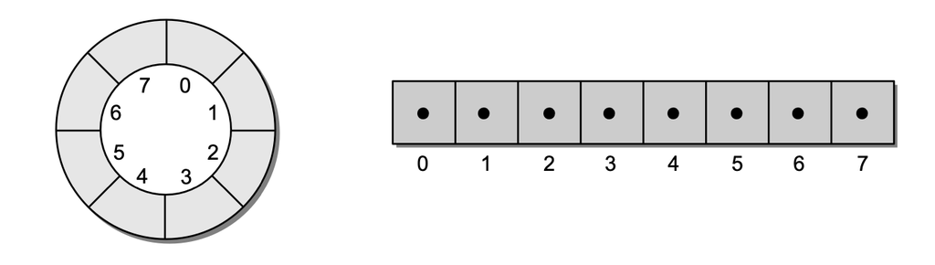

#### Circular Queue

- No need to shift items

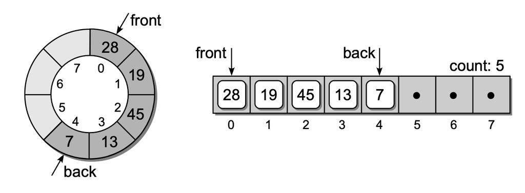

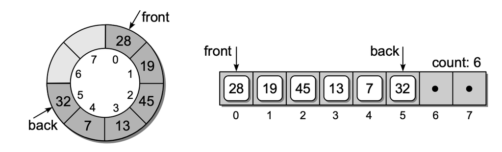

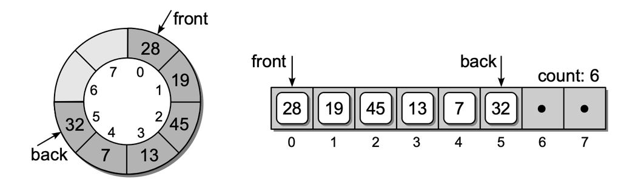

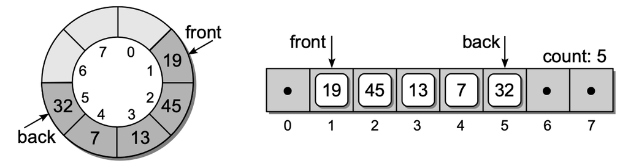

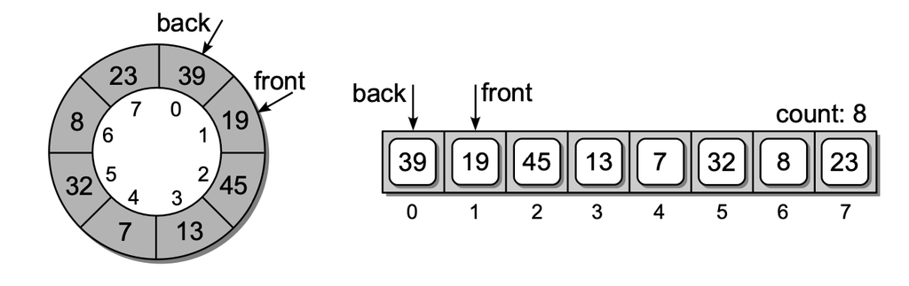

### What additional things will we need to implement a circular queue?

#### What are the additional things needed to implement a circular queue?

```
# Returns True if the queue is empty.
def isEmpty( self ):
    return len( self ) == 0

# Returns the number of items in the queue.
def __len__( self ):
    return len( self._qList )

# Adds the given item to the queue.
def enqueue( self, item ):
    self._qList.append( item )

# Removes and returns the first item in the queue.
def dequeue( self ):
    assert not self.isEmpty(), "Cannot dequeue from an empty queue."
    return self._qList.pop( 0 )
```

#### Circular Queue implementation

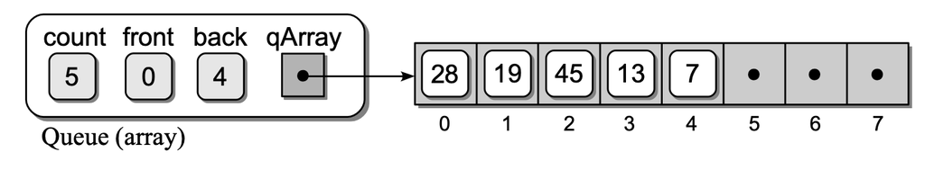

```python
# Implementation of the Circular Queue ADT using a Python list.
class cQueue :
    # Creates an empty queue.
    def __init__( self, maxSize ):
        self._qList = [-1] * maxSize
        self._count = 0
        self._front = 0
        self._back = maxSize - 1
        self._maxSize = maxSize

    # Returns True if the queue is empty.
    def isEmpty( self ):
        return self._count == 0

    # Returns True if the queue is full.
    def isFull( self ):
        return self._count == self._maxSize

    # Returns the number of items in the queue.
    def __len__( self ):
        return self._count

    # Adds the given item to the queue.
    def enqueue( self, item ):
        assert not self.isFull(), "Cannot enqueue to a full queue."
        self._back = (self._back + 1) % self._maxSize
        self._qList[self._back] = item
        self._count += 1

    # Removes and returns the first item in the queue.
    def dequeue( self ):
        assert not self.isEmpty(), "Cannot dequeue from an empty queue."
        item = self._qList[self._front]
        self._front = (self._front + 1) % self._maxSize
        self._count -= 1
        return item
```

```python
mycQ = cQueue(3)

print(mycQ.isEmpty())
mycQ.enqueue(4)
print(mycQ.isEmpty())
mycQ.enqueue(16)
mycQ.enqueue(9)
#mycQ.enqueue(22)

print(mycQ.dequeue())
print(mycQ.dequeue())
print(mycQ.dequeue())
print(mycQ.dequeue())
```

### Queue implemented as a Linked List

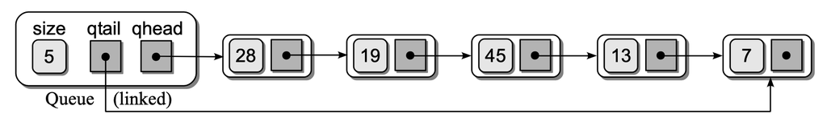

```python
# Implementation of the Queue ADT using a linked list.
class lQueue :

    # Creates an empty queue.
    def __init__( self ):
        self._qhead = None
        self._qtail = None
        self._count = 0

    # Returns True if the queue is empty.
    def isEmpty( self ):
        return self._qhead is None

    # Returns the number of items in the queue.
    def __len__( self ):
        return self._count

    # Adds the given item to the queue.
    def enqueue( self, item ):

        node = _QueueNode( item )

        if self.isEmpty() :
            self._qhead = node
        else :
            self._qtail.next = node

        self._qtail = node
        self._count += 1

    # Removes and returns the first item in the queue.
    def dequeue( self ):
        assert not self.isEmpty(), "Cannot dequeue from an empty queue."
        node = self._qhead

        if self._qhead is self._qtail :
            self._qtail = None

        self._qhead = self._qhead.next
        self._count -= 1
        return node.item

# Private storage class for creating the linked list nodes.
class _QueueNode( object ):
    def __init__( self, item ):
        self.item = item
        self.next = None
```

```python
mylQ = lQueue()
mylQ.enqueue(4)
mylQ.enqueue(12)
mylQ.enqueue(9)

print(mylQ.dequeue())
print(mylQ.dequeue())
print(mylQ.dequeue())
#print(mylQ.dequeue())
```

### Priority Queues

- Airlines board "first class" customers before "economy class"
- Hospital emergency rooms prioritse some emergencies over others
- Many restaurants seat VIPs before regular customers, even if the latter have reservations.

### Priority Queues

- A priority **p** must be assigned to each item at the time it is enqueued.
- An element with high priority is served before an element with low priority.
- The **bounded** priority queue assumes a small limited range of p priorities over the interval of integers [0 . . . p)
- The **unbounded** priority queue places no limit on the range of integer values that can be used as priorities.

#### Priority Queue

- A priority queue is a queue in which each item is assigned a priority and items with a higher priority are removed before those with a lower priority, irrespective of when they were added.
- A smaller integer value having a higher priority. (like ranks)

#### Priority Queue ADT

$\tt PriorityQueue( )$: Creates a new empty unbounded priority queue.

$\tt BPriorityQueue( numLevels )$: Creates a new empty bounded priority queue with priority levels in the range from 0 to numLevels - 1.

$\tt isEmpty( )$: Returns a boolean value indicating whether the queue is empty.

$\tt length ( )$: Returns the number of items currently in the queue.

#### Priority Queue ADT

$\tt enqueue( item, priority )$: Adds the given item to the queue by inserting it in the proper position based on the given priority. The priority value must be within the legal range when using a bounded priority queue.

$\tt dequeue( )$: Removes and returns the front item from the queue, which is the item with the highest priority. The associated priority value is discarded. If two items have the same priority, then those items are removed in a FIFO order. An item cannot be dequeued from an empty queue.

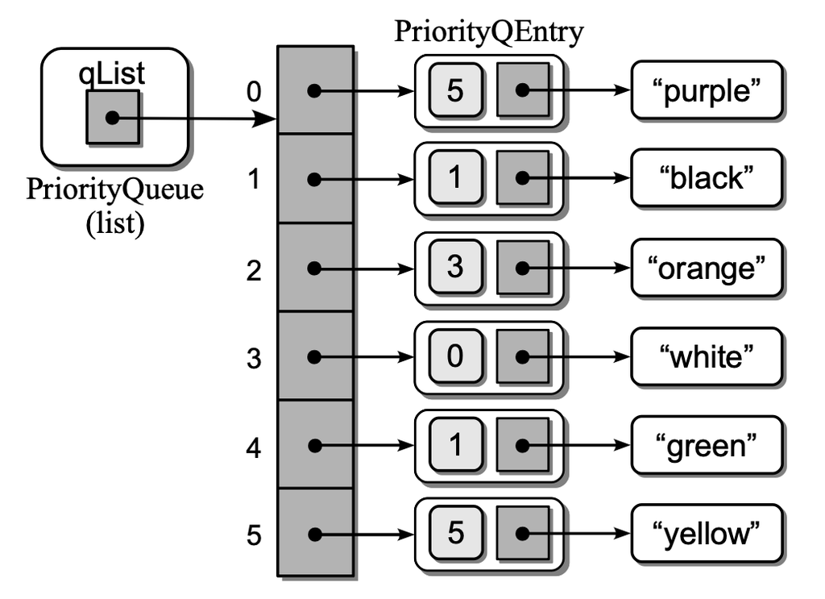

```python
# Implementation of the unbounded Priority Queue ADT using a Python list
# with new items appended to the end.

class PriorityQueue :


    # Create an empty unbounded priority queue.
    def __init__( self ):
        self._qList = list()

    # Returns True if the queue is empty.
    def isEmpty( self ):
        return len( self ) == 0

    # Returns the number of items in the queue.
    def __len__( self ):
        return len( self._qList )

    # Adds the given item to the queue.
    def enqueue( self, item, priority ):
        # Create a new instance of the storage class and append it to the list.
        entry = _PriorityQEntry( item, priority )
        self._qList.append( entry )

    # Removes and returns the first item in the queue.
    def dequeue( self ) :
        assert not self.isEmpty(), "Cannot dequeue from an empty queue."

    # Find the entry with the highest priority.
        highest = self._qList[0].priority
        highesti = 0

        for i in range( self.__len__() ) :
          # See if the ith entry contains a higher priority (smaller integer).
          if self._qList[i].priority < highest :
            highest = self._qList[i].priority
            highesti = i
            #print("higher..", highest)

        # Remove the entry with the highest priority and return the item.
        #print("highest", highest, highesti)
        entry = self._qList.pop( highesti )
        return entry.item

    # Print PQ
    def prnpq ( self ):
        for j in range( self.__len__() ):
            print(self._qList[j].item,self._qList[j].priority)

# Private storage class for associating queue items with their priority.
class _PriorityQEntry( object ):

    def __init__( self, item, priority ):
        self.item = item
        self.priority = priority
```

```python
Q = PriorityQueue(  )
Q.enqueue( "purple", 5 )
Q.enqueue( "black", 1 )
Q.enqueue( "orange", 3 )
Q.enqueue( "white", 0 )
Q.enqueue( "green", 1 )
Q.enqueue( "yellow", 5 )
Q.prnpq()
```

```python
while not Q.isEmpty() :
    item = Q.dequeue()
    print( item )
```

#### Priority Queue: Linked List Implementation

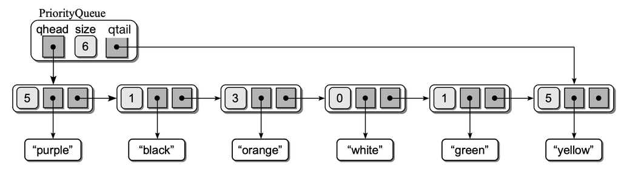

```python
class PriorityQueueL:


    # Create an empty unbounded priority queue.
    def __init__( self ):
        self._qhead = None
        self._qtail = None
        self._size = 0


    # Returns True if the queue is empty.
    def isEmpty( self ):
        return self._qhead is None

    # Returns the number of items in the queue.
    def __len__( self ):
        return self._size

    # Adds the given item to the queue.
    def enqueue( self, item, priority ):

        # Create a new instance of the storage class and append it to the list.
        node = _PriorityQEntryl( item, priority )

        if self.isEmpty() :
            self._qhead = node
        else :
            self._qtail.next = node

        self._qtail = node
        self._size += 1


    # Removes and returns the first item in the queue.
    def dequeue( self ) :

        assert not self.isEmpty(), "Cannot dequeue from an empty queue."

        # Find the entry with the highest priority.
        node = self._qhead

        highpri  = self._qhead.priority
        highnode = self._qhead

        #print("higher..", highnode.item, highnode.priority)

        while node !=  None :
            # See if the next entry contains a higher priority (smaller integer).
            if node.priority < highpri :
                highpri  = node.priority
                highnode = node
                prevhigh = prevnode # the node prev to highnode
                #print("higher..", highnode.next.item, highnode.next.priority)

            prevnode = node
            node = node.next


        # Remove the entry with the highest priority and return the item.
        node = highnode

        if self._size == 1:
            self._qtail = None
            self._qhead = None
            self._size = 0
        else:
            if node is self._qhead:
                self._qhead = self._qhead.next
            else:
                prevhigh.next = node.next

            self._size -= 1

        return node.item

    # Print PQ
    def prnpq ( self ):
        node = self._qhead
        while node != None:
            print(node.item,node.priority)
            node = node.next

# Private storage class for associating queue items with their priority.
class _PriorityQEntryl( object ):

    def __init__( self, item, priority ):
        self.item = item
        self.priority = priority
        self.next = None
```

```python
mypql = PriorityQueueL()
mypql.enqueue( "purple", 5 )
mypql.enqueue( "black", 1 )
mypql.enqueue( "orange", 3 )
mypql.enqueue( "white", 0 )
mypql.enqueue( "green", 1 )
mypql.enqueue( "yellow", 5 )
mypql.prnpq()
```

[figure not shown]

```python
while not mypql.isEmpty() :
    item = mypql.dequeue()
    print("-->", item )
```

$\tt dequeue( ) :\;$ Removes and returns the front item from the queue,

- the item with the highest priority.
- If two items have the same priority, then those items are removed in a FIFO order.

```python
# Implementation of the unbounded Priority Queue ADT using a Python list
# with new items appended to the end.

class PriorityQueue :


    # Create an empty unbounded priority queue.
    def __init__( self ):
        self._qList = list()

    # Returns True if the queue is empty.
    def isEmpty( self ):
        return len( self ) == 0

    # Returns the number of items in the queue.
    def __len__( self ):
        return len( self._qList )

    # Adds the given item to the queue.
    def enqueue( self, item, priority ):
        # Create a new instance of the storage class and append it to the list.
        entry = _PriorityQEntry( item, priority )
        self._qList.append( entry )

    # Removes and returns the first item in the queue.
    def dequeue( self ) :
        assert not self.isEmpty(), "Cannot dequeue from an empty queue."

    # Find the entry with the highest priority.
        highest = self._qList[0].priority
        highesti = 0

        for i in range( self.__len__() ) :
          # See if the ith entry contains a higher priority (smaller integer).
          if self._qList[i].priority < highest :
            highest = self._qList[i].priority
            highesti = i
            #print("higher..", highest)

        # Remove the entry with the highest priority and return the item.
        #print("highest", highest, highesti)
        entry = self._qList.pop( highesti )
        return entry.item

    # Print PQ
    def prnpq ( self ):
        for j in range( self.__len__() ):
            print(self._qList[j].item,self._qList[j].priority)

# Private storage class for associating queue items with their priority.
class _PriorityQEntry( object ):

    def __init__( self, item, priority ):
        self.item = item
        self.priority = priority
```

```python
my2list = [("a",1),("b",2),("c",3)]

def padd (plist,item,pri):
    plist.append((item,pri))

def pdel (plist):
    hipri_item = max(plist,key=lambda x:x[0])
    print(hipri_item)
```

```python
padd(my2list,"d",5)
print(my2list)
```

```python
pdel(my2list)
print(my2list)
```